# yuba-data-checks

Inigo Peng, edited by Badhia Yunes-Katz

2025-07-09

# Database Tables

## Yuba

### catch

**- Findings catch:**

- life stage in edi data has not gone through wrangling
- catch_raw_id in database has a decimal number (e.g 302.0)

#### Date Range Check

*EDI `date`*

```r
range(catch_yuba_edi$date)
```

```
## [1] "2022-11-22" "2025-06-27"
```

*DB `date`*

```
## [1] "2022-11-22" "2025-06-27"
```

#### ForkLength

*EDI `forkLength`*

- 2 % of values in the `forkLength` column are NA.

```
##    Min. 1st Qu.  Median    Mean 3rd Qu.    Max.    NA's
##    3.00   35.00   37.00   42.72   43.00  454.00     645
```

*DB `fork_length`*

- 2 % of values in the `fork_length` column are NA.

```
##    Min. 1st Qu.  Median    Mean 3rd Qu.    Max.    NA's
##    3.00   35.00   37.00   42.72   43.00  454.00     645
```

*Forklength Exploration Plots*

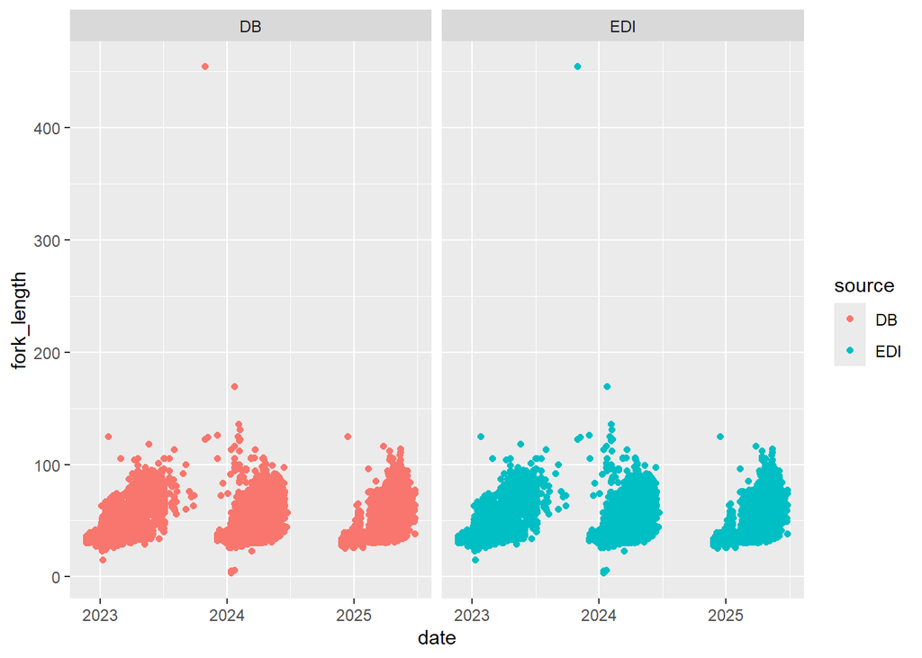

#### Lifestage

(life stage in edi data has not gone through wrangling)

*EDI `lifeStage`*

- 0 % of values in the `lifeStage` column from the EDI data are NA.

*DB `lifestage_id`*

- 0 % of values in the `lifestage_id` column from the database are NA.

#### Count

*EDI `n`*

- 0 % of values in the `n` column in edi data are NA.

```
##     Min.  1st Qu.   Median     Mean  3rd Qu.     Max.
##    1.000    1.000    1.000    3.566    1.000 5844.000
```

*DB `count`*

- 0 % of values in the `count` column in database data are NA.

```
##     Min.  1st Qu.   Median     Mean  3rd Qu.     Max.
##    1.000    1.000    1.000    3.566    1.000 5844.000
```

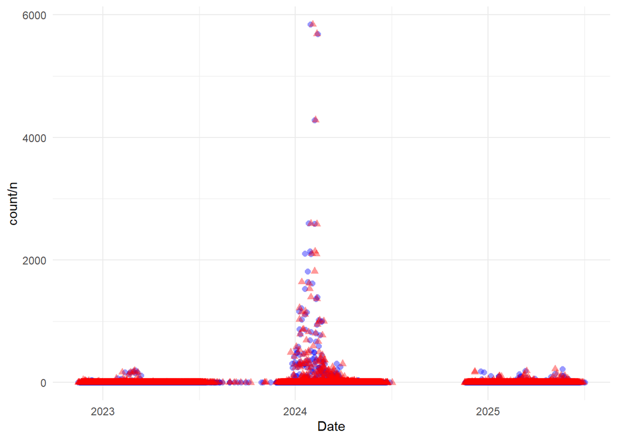

Random pick of data entry to compare between db and EDI

- test 1

```
## Rows: 1
## Columns: 17
## $ id               <int> 72059660
## $ catch_raw_id     <chr> "302.0"
## $ trap_location_id <int> 49
## $ date             <date> 2022-11-23
## $ count            <dbl> 1
## $ run_id           <int> 2
## $ lifestage_id     <int> 5
## $ adipose_clipped  <lgl> FALSE
## $ dead             <lgl> NA
## $ fork_length      <dbl> 36
## $ weight           <dbl> NA
## $ actual_count     <lgl> TRUE
## $ updated_at       <dttm> 2025-07-10 01:04:35
## $ stream           <chr> "yuba river"
## $ site             <chr> "hallwood"
## $ subsite          <chr> "hal3"
## $ source           <chr> "DB"
```

```
## Rows: 1
## Columns: 19
## $ visitTime            <dttm> 2022-11-23 09:02:09
## $ run                  <chr> "Spring"
## $ forkLength           <dbl> 36
## $ lifeStage            <chr> "Parr"
## $ n                    <dbl> 1
## $ siteName             <chr> "hallwood"
## $ subSiteName          <chr> "hal3"
## $ fishOrigin           <chr> "Natural"
## $ commonName           <chr> "Chinook salmon"
## $ releaseID            <dbl> 0
## $ ProjectDescriptionID <dbl> 7
## $ trapVisitID          <dbl> 60
## $ visitType            <chr> "End trapping"
## $ catchRawID           <dbl> 302
## $ totalLength          <dbl> NA
## $ actualCount          <chr> "Yes"
## $ stream               <chr> "yuba river"
## $ date                 <date> 2022-11-23
## $ source               <chr> "EDI"
```

- test 2

```
## Rows: 1
## Columns: 17
## $ id               <int> 72060539
## $ catch_raw_id     <chr> "18663.0"
## $ trap_location_id <int> 47
## $ date             <date> 2024-02-14
## $ count            <dbl> 1
## $ run_id           <int> 2
## $ lifestage_id     <int> 5
## $ adipose_clipped  <lgl> FALSE
## $ dead             <lgl> NA
## $ fork_length      <dbl> 55
## $ weight           <dbl> NA
## $ actual_count     <lgl> TRUE
## $ updated_at       <dttm> 2025-07-10 01:04:35
## $ stream           <chr> "yuba river"
## $ site             <chr> "hallwood"
## $ subsite          <chr> "hal"
## $ source           <chr> "DB"
```

```
## Rows: 1
## Columns: 19
## $ visitTime            <dttm> 2024-02-14 10:05:54
## $ run                  <chr> "Spring"
## $ forkLength           <dbl> 55
## $ lifeStage            <chr> "Parr"
## $ n                    <dbl> 1
## $ siteName             <chr> "hallwood"
## $ subSiteName          <chr> "hal"
## $ fishOrigin           <chr> "Natural"
## $ commonName           <chr> "Chinook salmon"
## $ releaseID            <dbl> 0
## $ ProjectDescriptionID <dbl> 7
## $ trapVisitID          <dbl> 923
## $ visitType            <chr> "Continue trapping"
## $ catchRawID           <dbl> 18663
## $ totalLength          <dbl> NA
## $ actualCount          <chr> "Yes"
## $ stream               <chr> "yuba river"
## $ date                 <date> 2024-02-14
## $ source               <chr> "EDI"
```

- test 3

```
## Rows: 1
## Columns: 17
## $ id               <int> 72072310
## $ catch_raw_id     <chr> "1525.0"
## $ trap_location_id <int> 47
## $ date             <date> 2023-01-06
## $ count            <dbl> 1
## $ run_id           <int> 3
## $ lifestage_id     <int> 2
## $ adipose_clipped  <lgl> FALSE
## $ dead             <lgl> NA
## $ fork_length      <dbl> 35
## $ weight           <dbl> NA
## $ actual_count     <lgl> TRUE
## $ updated_at       <dttm> 2025-07-10 01:04:35
## $ stream           <chr> "yuba river"
## $ site             <chr> "hallwood"
## $ subsite          <chr> "hal"
## $ source           <chr> "DB"
```

```
## Rows: 1
## Columns: 19
## $ visitTime            <dttm> 2023-01-06 09:30:28
## $ run                  <chr> "Fall"
## $ forkLength           <dbl> 28
## $ lifeStage            <chr> "Yolk sac fry (alevin)"
## $ n                    <dbl> 1
## $ siteName             <chr> "hallwood"
## $ subSiteName          <chr> "hal"
## $ fishOrigin           <chr> "Natural"
## $ commonName           <chr> "Chinook salmon"
## $ releaseID            <dbl> 0
## $ ProjectDescriptionID <dbl> 7
## $ trapVisitID          <dbl> 104
## $ visitType            <chr> "Continue trapping"
## $ catchRawID           <dbl> 1526
## $ totalLength          <dbl> NA
## $ actualCount          <chr> "Yes"
## $ stream               <chr> "yuba river"
## $ date                 <date> 2023-01-06
## $ source               <chr> "EDI"
```

### trap

#### Date Range Check

*DB `trap_visit_time_start`*

```
## [1] "2015-04-15 10:36:13 UTC" "2025-06-27 11:00:47 UTC"
```

*EDI `visitTime`*

```r
range(trap_yuba_edi$visitTime)
```

```
## [1] "2015-04-15 10:36:13 UTC" "2025-06-27 11:00:47 UTC"
```

#### counteratend/total_revolution

*DB `total_revolutions`*

- 11.5 % of values in the `total_revolutions` column are NA.

```
##    Min. 1st Qu.  Median    Mean 3rd Qu.    Max.    NA's
##       0    1425    2375    2683    3562   13775     216
```

*EDI `counterAtEnd`*

- 11.5 % of values in the `counterAtEnd` column are NA.

```
##    Min. 1st Qu.  Median    Mean 3rd Qu.    Max.    NA's
##       0    1425    2375    2683    3562   13775     216
```

#### fishProcessed

*DB `fish_processed_id`*

- 0 % of values in the `fish_processed_id` column are NA.

```
##
##    1    2    3    4
##  192 1482  200    2
```

*EDI `fishProcessed`*

- 0 % of values in the `fishProcessed` column are NA.

```
##
## No catch data; fish released          No fish were caught
##                            2                          200
##               Not applicable               Processed fish
##                          192                         1482
```

Random pick of data entry by date to compare between db and EDI

- test 1

```
## Rows: 1
## Columns: 25
## $ id                         <int> 3373000
## $ trap_location_id           <int> 49
## $ trap_visit_id              <chr> "986"
## $ visit_type_id              <int> 2
## $ trap_visit_time_start      <dttm> 2024-02-24 11:32:10
## $ trap_visit_time_end        <dttm> NA
## $ trap_functioning_id        <int> 2
## $ in_half_cone_configuration <lgl> NA
## $ fish_processed_id          <int> 2
## $ rpm_start                  <dbl> 0
## $ rpm_end                    <dbl> 0
## $ total_revolutions          <dbl> 47
## $ debris_volume              <dbl> NA
## $ debris_level_id            <int> NA
## $ discharge                  <dbl> NA
## $ water_velocity             <dbl> NA
## $ water_temp                 <dbl> 10
## $ turbidity                  <dbl> 9
## $ include                    <lgl> TRUE
## $ updated_at                 <dttm> 2025-07-10 01:05:04
## $ updated_by                 <chr> "AdminJPE"
## $ stream                     <chr> "yuba river"
## $ site                       <chr> "hallwood"
## $ subsite                    <chr> "hal3"
## $ source                     <chr> "DB"
```

```
## Rows: 1
## Columns: 17
## $ counterAtEnd          <dbl> 47
## $ siteName              <chr> "hallwood"
## $ subSiteName           <chr> "hal3"
## $ rpmRevolutionsAtStart <dbl> 0
## $ rpmRevolutionsAtEnd   <dbl> 0
## $ waterTemp             <dbl> 10
## $ turbidity             <dbl> 9
## $ visitTime             <dttm> 2024-02-24 11:32:10
## $ visitType             <chr> "Continue trapping"
## $ trapFunctioning       <chr> "Trap functioning normally"
## $ fishProcessed         <chr> "Processed fish"
## $ includeCatch          <chr> "Yes"
## $ projectDescriptionID  <dbl> 7
## $ trapVisitID           <dbl> 986
## $ stream                <chr> "yuba river"
## $ date                  <date> 2024-02-24
## $ source                <chr> "EDI"
```

- test 2

```
## Rows: 1
## Columns: 25
## $ id                         <int> 3372702
## $ trap_location_id           <int> 49
## $ trap_visit_id              <chr> "1270"
## $ visit_type_id              <int> 2
## $ trap_visit_time_start      <dttm> 2024-06-02 11:04:25
## $ trap_visit_time_end        <dttm> NA
## $ trap_functioning_id        <int> 2
## $ in_half_cone_configuration <lgl> NA
## $ fish_processed_id          <int> 3
## $ rpm_start                  <dbl> 0
## $ rpm_end                    <dbl> 0.2
## $ total_revolutions          <dbl> 617
## $ debris_volume              <dbl> NA
## $ debris_level_id            <int> NA
## $ discharge                  <dbl> NA
## $ water_velocity             <dbl> NA
## $ water_temp                 <dbl> 13
## $ turbidity                  <dbl> 1.49
## $ include                    <lgl> TRUE
## $ updated_at                 <dttm> 2025-07-10 01:05:04
## $ updated_by                 <chr> "AdminJPE"
## $ stream                     <chr> "yuba river"
## $ site                       <chr> "hallwood"
## $ subsite                    <chr> "hal3"
## $ source                     <chr> "DB"
```

```
## Rows: 1
## Columns: 17
## $ counterAtEnd          <dbl> 617
## $ siteName              <chr> "hallwood"
## $ subSiteName           <chr> "hal3"
## $ rpmRevolutionsAtStart <dbl> 0
## $ rpmRevolutionsAtEnd   <dbl> 0.2
## $ waterTemp             <dbl> 13
## $ turbidity             <dbl> 1.49
## $ visitTime             <dttm> 2024-06-02 11:04:25
## $ visitType             <chr> "Continue trapping"
## $ trapFunctioning       <chr> "Trap functioning normally"
## $ fishProcessed         <chr> "No fish were caught"
## $ includeCatch          <chr> "Yes"
## $ projectDescriptionID  <dbl> 7
## $ trapVisitID           <dbl> 1270
## $ stream                <chr> "yuba river"
## $ date                  <date> 2024-06-02
## $ source                <chr> "EDI"
```

- test 3

```
## Rows: 1
## Columns: 25
## $ id                         <int> 3372947
## $ trap_location_id           <int> 49
## $ trap_visit_id              <chr> "549"
## $ visit_type_id              <int> 2
## $ trap_visit_time_start      <dttm> 2023-06-10 10:52:01
## $ trap_visit_time_end        <dttm> NA
## $ trap_functioning_id        <int> 2
## $ in_half_cone_configuration <lgl> NA
## $ fish_processed_id          <int> 2
## $ rpm_start                  <dbl> 5.8
## $ rpm_end                    <dbl> 4.1
## $ total_revolutions          <dbl> 5225
## $ debris_volume              <dbl> NA
## $ debris_level_id            <int> NA
## $ discharge                  <dbl> NA
## $ water_velocity             <dbl> NA
## $ water_temp                 <dbl> 12
## $ turbidity                  <dbl> 2.03
## $ include                    <lgl> TRUE
## $ updated_at                 <dttm> 2025-07-10 01:05:04
## $ updated_by                 <chr> "AdminJPE"
## $ stream                     <chr> "yuba river"
## $ site                       <chr> "hallwood"
## $ subsite                    <chr> "hal3"
## $ source                     <chr> "DB"
```

```
## Rows: 1
## Columns: 17
## $ counterAtEnd          <dbl> 5225
## $ siteName              <chr> "hallwood"
## $ subSiteName           <chr> "hal3"
## $ rpmRevolutionsAtStart <dbl> 5.8
## $ rpmRevolutionsAtEnd   <dbl> 4.1
## $ waterTemp             <dbl> 12
## $ turbidity             <dbl> 2.03
## $ visitTime             <dttm> 2023-06-10 10:52:01
## $ visitType             <chr> "Continue trapping"
## $ trapFunctioning       <chr> "Trap functioning normally"
## $ fishProcessed         <chr> "Processed fish"
## $ includeCatch          <chr> "Yes"
## $ projectDescriptionID  <dbl> 7
## $ trapVisitID           <dbl> 549
## $ stream                <chr> "yuba river"
## $ date                  <date> 2023-06-10
## $ source                <chr> "EDI"
```

- test 4

```
## Rows: 1
## Columns: 25
## $ id                         <int> 3373946
## $ trap_location_id           <int> 48
## $ trap_visit_id              <chr> "1071"
## $ visit_type_id              <int> 2
## $ trap_visit_time_start      <dttm> 2024-03-27 11:15:02
## $ trap_visit_time_end        <dttm> NA
## $ trap_functioning_id        <int> 2
## $ in_half_cone_configuration <lgl> NA
## $ fish_processed_id          <int> 2
## $ rpm_start                  <dbl> 2.4
## $ rpm_end                    <dbl> 3.3
## $ total_revolutions          <dbl> 3800
## $ debris_volume              <dbl> NA
## $ debris_level_id            <int> NA
## $ discharge                  <dbl> NA
## $ water_velocity             <dbl> NA
## $ water_temp                 <dbl> 10
## $ turbidity                  <dbl> 1.77
## $ include                    <lgl> TRUE
## $ updated_at                 <dttm> 2025-07-10 01:05:04
## $ updated_by                 <chr> "AdminJPE"
## $ stream                     <chr> "yuba river"
## $ site                       <chr> "hallwood"
## $ subsite                    <chr> "hal2"
## $ source                     <chr> "DB"
```

```
## Rows: 1
## Columns: 17
## $ counterAtEnd          <dbl> 3800
## $ siteName              <chr> "hallwood"
## $ subSiteName           <chr> "hal2"
## $ rpmRevolutionsAtStart <dbl> 2.4
## $ rpmRevolutionsAtEnd   <dbl> 3.3
## $ waterTemp             <dbl> 10
## $ turbidity             <dbl> 1.77
## $ visitTime             <dttm> 2024-03-27 11:15:02
## $ visitType             <chr> "Continue trapping"
## $ trapFunctioning       <chr> "Trap functioning normally"
## $ fishProcessed         <chr> "Processed fish"
## $ includeCatch          <chr> "Yes"
## $ projectDescriptionID  <dbl> 7
## $ trapVisitID           <dbl> 1071
## $ stream                <chr> "yuba river"
## $ date                  <date> 2024-03-27
## $ source                <chr> "EDI"
```

### release

**- Findings:**

- date and time range are the same
- there is not markedLifeStage column in EDI

#### Date Range Check

*DB `date_released`*

```
## [1] "2022-09-01 12:48:48 UTC" "2025-05-13 12:16:12 UTC"
```

*EDI `releaseTime`*

```r
range(release_yuba_edi$releaseTime)
```

```
## [1] "2022-09-01 12:48:48 UTC" "2025-05-13 12:16:12 UTC"
```

#### origin_id

*EDI `markedFishOrigin`*

- 0 % of values in the `markedFishOrigin` column are NA.

```
##
## Hatchery  Natural
##       29       35
```

*DB `origin_id`*

- 0 % of values in the `origin_id` column are NA.

```
##
##  1  2
## 35 29
```

#### nReleased

*EDI `nReleased`*

- 0 % of values in the `nReleased` column are NA.

```
##    Min. 1st Qu.  Median    Mean 3rd Qu.    Max.
##    22.0   281.8   522.0   630.5   988.2  2018.0
```

*DB `number_released`*

- 0 % of values in the `number_released` column are NA.

```
##    Min. 1st Qu.  Median    Mean 3rd Qu.    Max.
##    22.0   281.8   522.0   630.5   988.2  2018.0
```

*Exploration Plots*

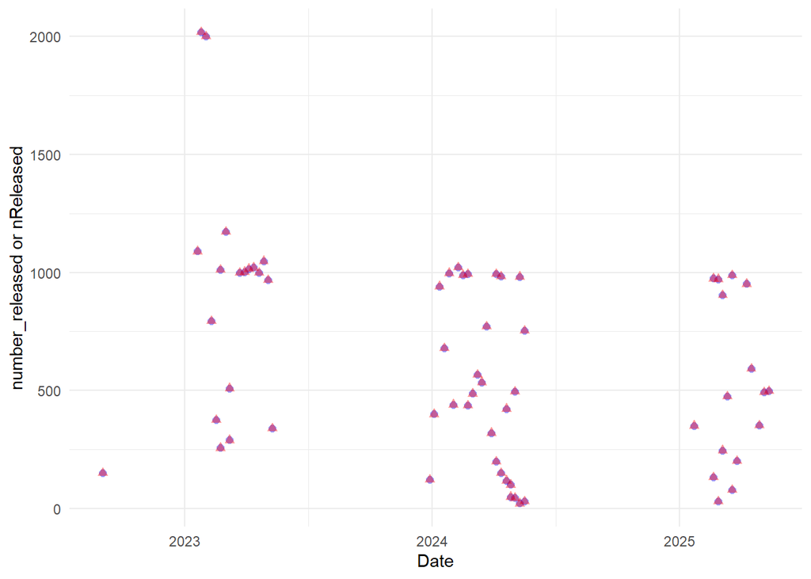

Random pick of data entry by date to compare between db and EDI

- test 1

```
## Rows: 1
## Columns: 15
## $ id                          <int> 128483
## $ trap_location_id            <int> 50
## $ release_id                  <chr> "297"
## $ date_released               <dttm> 2024-04-12 09:30:12
## $ run_id                      <int> 3
## $ median_fork_length_released <dbl> NA
## $ lifestage_id                <int> NA
## $ origin_id                   <int> 1
## $ number_released             <dbl> 150
## $ updated_at                  <dttm> 2025-07-10 01:05:03
## $ updated_by                  <chr> "AdminJPE"
## $ stream                      <chr> "yuba river"
## $ site                        <chr> "hallwood"
## $ subsite                     <chr> NA
## $ source                      <chr> "DB"
```

```
## Rows: 1
## Columns: 19
## $ projectDescriptionID <dbl> 7
## $ releaseID            <dbl> 297
## $ releaseTime          <dttm> 2024-04-12 09:30:12
## $ commonName           <chr> "Chinook salmon"
## $ markedRun            <chr> "Fall"
## $ markedFishOrigin     <chr> "Natural"
## $ sourceOfFishSite     <chr> "Hallwood"
## $ releaseSite          <chr> "hallwood release site"
## $ releaseSubSite       <chr> NA
## $ nReleased            <dbl> 150
## $ testDays             <dbl> 7
## $ appliedMarkType      <chr> "Elastomer"
## $ appliedMarkColor     <chr> "Yellow"
## $ appliedMarkPosition  <chr> "Nose"
## $ appliedMarkCode      <lgl> NA
## $ IncludeInAnalysis    <chr> "Yes"
## $ stream               <chr> "yuba river"
## $ date                 <date> 2024-04-12
## $ source               <chr> "EDI"
```

- test 2

```
## Rows: 1
## Columns: 15
## $ id                          <int> 128448
## $ trap_location_id            <int> 50
## $ release_id                  <chr> "257"
## $ date_released               <dttm> 2023-01-19 22:27:12
## $ run_id                      <int> 3
## $ median_fork_length_released <dbl> NA
## $ lifestage_id                <int> NA
## $ origin_id                   <int> 2
## $ number_released             <dbl> 1090
## $ updated_at                  <dttm> 2025-07-10 01:05:03
## $ updated_by                  <chr> "AdminJPE"
## $ stream                      <chr> "yuba river"
## $ site                        <chr> "hallwood"
## $ subsite                     <chr> NA
## $ source                      <chr> "DB"
```

```
## Rows: 1
## Columns: 19
## $ projectDescriptionID <dbl> 7
## $ releaseID            <dbl> 257
## $ releaseTime          <dttm> 2023-01-19 22:27:12
## $ commonName           <chr> "Chinook salmon"
## $ markedRun            <chr> "Fall"
## $ markedFishOrigin     <chr> "Hatchery"
## $ sourceOfFishSite     <chr> "Not recorded"
## $ releaseSite          <chr> "hallwood release site"
## $ releaseSubSite       <chr> NA
## $ nReleased            <dbl> 1090
## $ testDays             <dbl> 7
## $ appliedMarkType      <chr> "Pigment / dye"
## $ appliedMarkColor     <chr> "Brown"
## $ appliedMarkPosition  <chr> "Whole body"
## $ appliedMarkCode      <lgl> NA
## $ IncludeInAnalysis    <chr> "Yes"
## $ stream               <chr> "yuba river"
## $ date                 <date> 2023-01-19
## $ source               <chr> "EDI"
```

- test 3

```
## Rows: 1
## Columns: 15
## $ id                          <int> 128450
## $ trap_location_id            <int> 50
## $ release_id                  <chr> "259"
## $ date_released               <dttm> 2023-02-01 12:15:12
## $ run_id                      <int> 3
## $ median_fork_length_released <dbl> NA
## $ lifestage_id                <int> NA
## $ origin_id                   <int> 2
## $ number_released             <dbl> 2001
## $ updated_at                  <dttm> 2025-07-10 01:05:03
## $ updated_by                  <chr> "AdminJPE"
## $ stream                      <chr> "yuba river"
## $ site                        <chr> "hallwood"
## $ subsite                     <chr> NA
## $ source                      <chr> "DB"
```

```
## Rows: 1
## Columns: 19
## $ projectDescriptionID <dbl> 7
## $ releaseID            <dbl> 259
## $ releaseTime          <dttm> 2023-02-01 12:15:12
## $ commonName           <chr> "Chinook salmon"
## $ markedRun            <chr> "Fall"
## $ markedFishOrigin     <chr> "Hatchery"
## $ sourceOfFishSite     <chr> "Not recorded"
## $ releaseSite          <chr> "hallwood release site"
## $ releaseSubSite       <chr> NA
## $ nReleased            <dbl> 2001
## $ testDays             <dbl> 7
## $ appliedMarkType      <chr> "Pigment / dye"
## $ appliedMarkColor     <chr> "Brown"
## $ appliedMarkPosition  <chr> "Whole body"
## $ appliedMarkCode      <lgl> NA
## $ IncludeInAnalysis    <chr> "Yes"
## $ stream               <chr> "yuba river"
## $ date                 <date> 2023-02-01
## $ source               <chr> "EDI"
```

- test 4

```
## Rows: 1
## Columns: 15
## $ id                          <int> 128454
## $ trap_location_id            <int> 50
## $ release_id                  <chr> "262"
## $ date_released               <dttm> 2023-02-22 10:55:12
## $ run_id                      <int> 3
## $ median_fork_length_released <dbl> NA
## $ lifestage_id                <int> NA
## $ origin_id                   <int> 2
## $ number_released             <dbl> 1011
## $ updated_at                  <dttm> 2025-07-10 01:05:03
## $ updated_by                  <chr> "AdminJPE"
## $ stream                      <chr> "yuba river"
## $ site                        <chr> "hallwood"
## $ subsite                     <chr> NA
## $ source                      <chr> "DB"
```

```
## Rows: 1
## Columns: 19
## $ projectDescriptionID <dbl> 7
## $ releaseID            <dbl> 262
## $ releaseTime          <dttm> 2023-02-22 10:55:12
## $ commonName           <chr> "Chinook salmon"
## $ markedRun            <chr> "Fall"
## $ markedFishOrigin     <chr> "Hatchery"
## $ sourceOfFishSite     <chr> "Not recorded"
## $ releaseSite          <chr> "hallwood release site"
## $ releaseSubSite       <chr> NA
## $ nReleased            <dbl> 1011
## $ testDays             <dbl> 7
## $ appliedMarkType      <chr> "Elastomer"
## $ appliedMarkColor     <chr> "Pink"
## $ appliedMarkPosition  <chr> "Nose"
## $ appliedMarkCode      <lgl> NA
## $ IncludeInAnalysis    <chr> "Yes"
## $ stream               <chr> "yuba river"
## $ date                 <date> 2023-02-22
## $ source               <chr> "EDI"
```

### recapture

**- Findings:**

- Same date range

#### Date Range Check

*DB `date`*

```
## [1] "2023-01-20" "2024-05-18"
```

*EDI `date`*

```r
range(recapture_yuba_edi$date)
```

```
## [1] "2023-01-20" "2024-05-18"
```

#### Count

*DB `count`*

- 0 % of values in the `count` column are NA.

```
##    Min. 1st Qu.  Median    Mean 3rd Qu.    Max.
##   1.000   1.000   1.000   1.893   1.000  37.000
```

*EDI `n`*

- 0 % of values in the `n` column are NA.

```r
summary(recapture_yuba_edi$n)
```

```
##    Min. 1st Qu.  Median    Mean 3rd Qu.    Max.
##   1.000   1.000   1.000   1.893   1.000  37.000
```

#### lifeStage

*EDI `lifeStage`*

- 0 % of values in the `lifeStage` column are NA.

```
##
##          Fry Not recorded         Parr Silvery parr
##          131           84           76           17
```

*DB `lifestage_id`*

- 0 % of values in the `lifestage_id` column are NA.

```
##
##   2   4   5   6
## 131  84  76  17
```

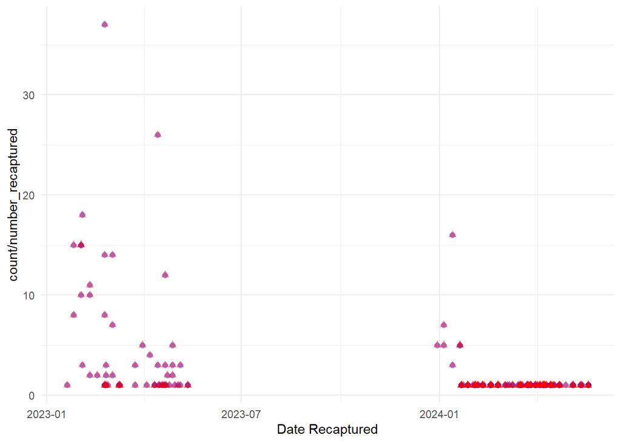

#### forkLength

*EDI `forkLength`*

- 21.1 % of values in the `forkLength` column are NA.

*DB `fork_length`*

- 21.1 % of values in the `fork_length` column are NA.

Random pick of data entry to compare between db and EDI

- test 1

```
## Rows: 1
## Columns: 17
## $ id               <int> 376094
## $ trap_location_id <int> 49
## $ catch_raw_id     <int> 6045
## $ date             <date> 2023-02-25
## $ count            <dbl> 1
## $ run_id           <int> 5
## $ lifestage_id     <int> 4
## $ adipose_clipped  <lgl> FALSE
## $ dead             <lgl> NA
## $ fork_length      <dbl> NA
## $ weight           <dbl> NA
## $ release_id       <chr> "263"
## $ updated_at       <dttm> 2025-07-10 01:05:02
## $ stream           <chr> "yuba river"
## $ site             <chr> "hallwood"
## $ subsite          <chr> "hal3"
## $ source           <chr> "DB"
```

```
## Rows: 1
## Columns: 21
## $ ProjectDescriptionID <dbl> 7
## $ catchRawID           <dbl> 6045
## $ trapVisitID          <dbl> 231
## $ commonName           <chr> "Chinook salmon"
## $ releaseID            <dbl> 263
## $ run                  <lgl> NA
## $ fishOrigin           <chr> "Natural"
## $ lifeStage            <chr> "Not recorded"
## $ forkLength           <dbl> NA
## $ n                    <dbl> 1
## $ visitTime            <dttm> 2023-02-25 09:45:39
## $ visitType            <chr> "Continue trapping"
## $ siteName             <chr> "hallwood"
## $ subSiteName          <chr> "hal3"
## $ markType             <chr> "Elastomer"
## $ markColor            <chr> "Yellow"
## $ markPosition         <chr> "Nose"
## $ markCode             <lgl> NA
## $ stream               <chr> "yuba river"
## $ date                 <date> 2023-02-25
## $ source               <chr> "EDI"
```

- test 2

```
## Rows: 1
## Columns: 17
## $ id               <int> 376160
## $ trap_location_id <int> 47
## $ catch_raw_id     <int> 16612
## $ date             <date> 2024-01-27
## $ count            <dbl> 1
## $ run_id           <int> 5
## $ lifestage_id     <int> 2
## $ adipose_clipped  <lgl> FALSE
## $ dead             <lgl> NA
## $ fork_length      <dbl> 36
## $ weight           <dbl> NA
## $ release_id       <chr> "279"
## $ updated_at       <dttm> 2025-07-10 01:05:02
## $ stream           <chr> "yuba river"
## $ site             <chr> "hallwood"
## $ subsite          <chr> "hal"
## $ source           <chr> "DB"
```

```
## Rows: 1
## Columns: 21
## $ ProjectDescriptionID <dbl> 7
## $ catchRawID           <dbl> 16612
## $ trapVisitID          <dbl> 893
## $ commonName           <chr> "Chinook salmon"
## $ releaseID            <dbl> 279
## $ run                  <lgl> NA
## $ fishOrigin           <chr> "Natural"
## $ lifeStage            <chr> "Fry"
## $ forkLength           <dbl> 36
## $ n                    <dbl> 1
## $ visitTime            <dttm> 2024-01-27 11:05:20
## $ visitType            <chr> "Continue trapping"
## $ siteName             <chr> "hallwood"
## $ subSiteName          <chr> "hal"
## $ markType             <chr> "Elastomer"
## $ markColor            <chr> "Yellow"
## $ markPosition         <chr> "Nose"
## $ markCode             <lgl> NA
## $ stream               <chr> "yuba river"
## $ date                 <date> 2024-01-27
## $ source               <chr> "EDI"
```

- test 3

```
## Rows: 1
## Columns: 17
## $ id               <int> 376229
## $ trap_location_id <int> 48
## $ catch_raw_id     <int> 19678
## $ date             <date> 2024-02-17
## $ count            <dbl> 1
## $ run_id           <int> 5
## $ lifestage_id     <int> 2
## $ adipose_clipped  <lgl> FALSE
## $ dead             <lgl> NA
## $ fork_length      <dbl> 34
## $ weight           <dbl> NA
## $ release_id       <chr> "282"
## $ updated_at       <dttm> 2025-07-10 01:05:02
## $ stream           <chr> "yuba river"
## $ site             <chr> "hallwood"
## $ subsite          <chr> "hal2"
## $ source           <chr> "DB"
```

```
## Rows: 1
## Columns: 21
## $ ProjectDescriptionID <dbl> 7
## $ catchRawID           <dbl> 19678
## $ trapVisitID          <dbl> 938
## $ commonName           <chr> "Chinook salmon"
## $ releaseID            <dbl> 282
## $ run                  <lgl> NA
## $ fishOrigin           <chr> "Natural"
## $ lifeStage            <chr> "Fry"
## $ forkLength           <dbl> 34
## $ n                    <dbl> 1
## $ visitTime            <dttm> 2024-02-17 10:05:56
## $ visitType            <chr> "Continue trapping"
## $ siteName             <chr> "hallwood"
## $ subSiteName          <chr> "hal2"
## $ markType             <chr> "Elastomer"
## $ markColor            <chr> "Yellow"
## $ markPosition         <chr> "Nose"
## $ markCode             <lgl> NA
## $ stream               <chr> "yuba river"
## $ date                 <date> 2024-02-17
## $ source               <chr> "EDI"
```

- test 4

```
## Rows: 1
## Columns: 17
## $ id               <int> 376330
## $ trap_location_id <int> 47
## $ catch_raw_id     <int> 26312
## $ date             <date> 2024-04-06
## $ count            <dbl> 1
## $ run_id           <int> 5
## $ lifestage_id     <int> 5
## $ adipose_clipped  <lgl> FALSE
## $ dead             <lgl> NA
## $ fork_length      <dbl> 56
## $ weight           <dbl> NA
## $ release_id       <chr> "291"
## $ updated_at       <dttm> 2025-07-10 01:05:02
## $ stream           <chr> "yuba river"
## $ site             <chr> "hallwood"
## $ subsite          <chr> "hal"
## $ source           <chr> "DB"
```

```
## Rows: 1
## Columns: 21
## $ ProjectDescriptionID <dbl> 7
## $ catchRawID           <dbl> 26312
## $ trapVisitID          <dbl> 1090
## $ commonName           <chr> "Chinook salmon"
## $ releaseID            <dbl> 291
## $ run                  <lgl> NA
## $ fishOrigin           <chr> "Natural"
## $ lifeStage            <chr> "Parr"
## $ forkLength           <dbl> 56
## $ n                    <dbl> 1
## $ visitTime            <dttm> 2024-04-06 10:00:29
## $ visitType            <chr> "Continue trapping"
## $ siteName             <chr> "hallwood"
## $ subSiteName          <chr> "hal"
## $ markType             <chr> "Elastomer"
## $ markColor            <chr> "Pink"
## $ markPosition         <chr> "Nose"
## $ markCode             <lgl> NA
## $ stream               <chr> "yuba river"
## $ date                 <date> 2024-04-06
## $ source               <chr> "EDI"
```